# MP4

Sarah Gillespie, Berry Williams, Eva Putnam

2019-05-09

Accessed on May 9, 2019

### The Cycle-ology of NYC’s Citi Bikes

###### By Sarah Gillespie, Eva Putnam, and Berry Williams

[figure not shown]

> Word count: 840

In 2013, Citibank and several other sponsors founded Citi Bike, the largest bike sharing system in the nation. Citi Bike provides a network of docking stations throughout New York City, primarily Manhattan, northwestern Brooklyn, and eastern Jersey City. People can unlock a bike for use then return it to any other station, including one-way trips. This environmentally-friendly service is available on a subscription and single ride business model, with a subscription priced at $15 per month and single rides priced at $3 per 30 minutes. This is a more economical mode of transportation than many alternatives such as taxis or ride-shares, such as Lyft and Uber.

```r
library(mdsr)
library(RMySQL)
library(tidyverse)
library(dplyr)
library(ggplot2)
library(sf)
library(leaflet)
library(lwgeom)
library(wordcountaddin)
library(lubridate)
library(rtweet)
library(RColorBrewer)
library(ggthemes)
```

```r
library(RMySQL)
db <- dbConnect(MySQL(),
                host = "scidb.smith.edu",
                user = "mth292",
                password = "RememberPi",
                dbname = "citibike")
class(db)
```

```
## [1] "MySQLConnection"
## attr(,"package")
## [1] "RMySQL"
```

```r
bikeStations <- db %>%
  dbGetQuery("SELECT *
             FROM station_summary;")
bikeStations <- bikeStations %>%
  filter(num_months > 8)
```

```r
MinutesOfSubscriber <- db %>%
  dbGetQuery("SELECT SUM(duration) AS minutes_ridden, user_type, start_time
              FROM trips
              GROUP BY MONTH(start_time), user_type;")
# more minutes on the bike leads to more likely to get hit by a car. Customers have 3  billion minutes whereas subscribers have 11 million minutes
#This is a big query and MySQL is super slow at it. There's probably nothing wrong with your computer but it did take about 2 minutes to execute on my computer.
```

We wanted to see how many locals used the bikes compared to tourists and what the Citi Bike experience entailed. Commuters double the population of Manhattan, going from 1.6 million to 3.1 million, according to a 2013 article from [The New York Times](https://cityroom.blogs.nytimes.com/2013/06/03/commuters-nearly-double-manhattans-daytime-population-census-says/?_r=0). New York City’s open categorized the Citi Bike users as subscribers, those riding with an annual membership, and customers, those riding with a single-ride ticket.

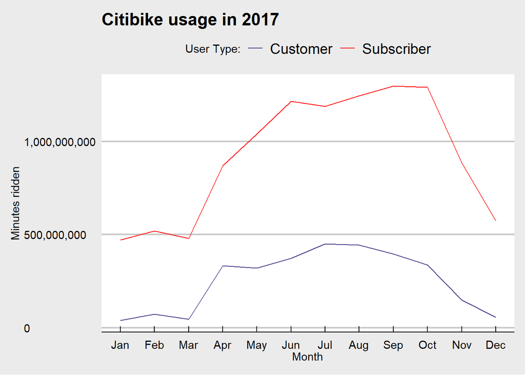

```r
MinutesOfSubscriberClean <- MinutesOfSubscriber %>%
  mutate(month = month(start_time)) %>%
  select(-start_time) %>%
  filter(user_type != "NA")

ggplot(MinutesOfSubscriberClean, aes(x = month, y = minutes_ridden, col = user_type)) +
  geom_line() +
  scale_y_continuous(name="Minutes ridden", labels = scales::comma) +
  ggtitle("Citibike usage in 2017") +
  xlab("Month") +
  labs(color = "User Type:") +
  scale_x_continuous(breaks = c(1,2,3,4,5,6,7,8,9,10,11,12), labels = c("Jan", "Feb", "Mar", "Apr", "May", "Jun", "Jul", "Aug", "Sep", "Oct", "Nov", "Dec")) +
  scale_color_manual(values = c("darkslateblue", "red")) +
  theme_economist_white()
```

Subscriptions overwhelmingly make up the majority of Citi Bike usage. The total minutes per month by each category illustrates the “bread and butter” of Citi Bike users are the people who purchase a subscription to the service, peaking in September with nearly 1.3 billion minutes compared to customers, those who purchase a single 30-minute ride, riding Citi Bike for 390 million minutes that same month. January is when Citi Bike is least used with customers cycling for only 39 million minutes but subscribers finished with a healthy 470 million minutes.

```r
citibikeTweets <- search_tweets("citibike nyc", n = 1000, include_rts = FALSE)
# you can only collect a eighteen thousand tweets every 15 minutes. There is also a monthly limit. You need an active Twitter account to be able to suceesfully use hte rtweet package and run this chunk of code. result: this makes a data table of tweets from the past 7 days.
```

```r
citibikeSimple <- citibikeTweets %>%
  select(status_id, screen_name, created_at, text, display_text_width, favorite_count, retweet_count, hashtags) %>%
  mutate(month = month(created_at, label = TRUE)) %>%
  mutate(day = day(created_at)) %>%
  mutate(hour = hour(created_at)) %>%
  mutate(minuteofHour = (minute(created_at))/(60)) %>%
  mutate(TimeOfDay = hour+minuteofHour)

#the twitter data has 88 columns so we are making a new data table that only include the columns that our project will be using.
```

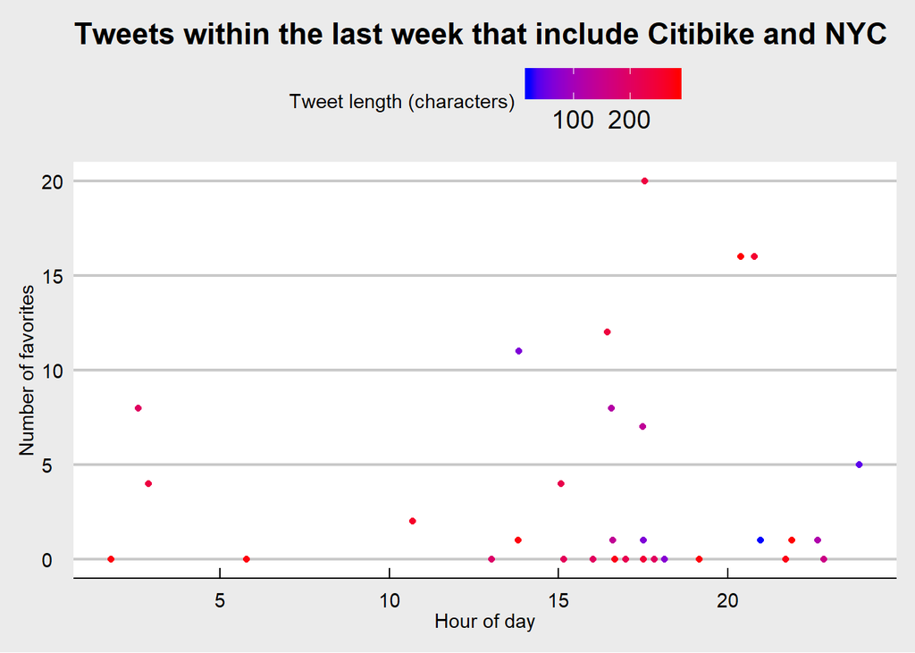

```r
ggplot(citibikeSimple, aes(x = TimeOfDay, y = favorite_count, color = display_text_width)) +
  geom_point() +
  scale_color_gradient(low="blue", high="red") +
  theme_classic() +
  ggtitle("Tweets within the last week that include Citibike and NYC") +
  xlab("Hour of day") +
  ylab('Number of favorites') +
  labs(color = "Tweet length (characters)") +
  theme(axis.title.y = element_text(angle = 0)) +
  theme_economist_white()
```

```r
#this shows how many likes that each tweet recieved. From Saturday nigth to the early morning of Thursday, May 9th most tweets and "favoritees" occured during the rush hour of 4 to 8 pm. We assume that will hold true but we cannot guaruntee the strength of that correlation in the future.
```

Twitter conversation about Citi Bikes in the city spiked during the rush hour between 4 and 8 p.m. during the week of May 5, 2019. The Twitter data graphic finds tweets about both New York City and Citi Bike in real time and only includes data from the most recent seven days so this correlation may intensify or weaken based on the time of year.

```r
joinedTableSimple <- db %>%
  dbGetQuery("SELECT
                station_months.station_id AS smonID, station_months.name AS smonName, station_summary.num_months AS ssumNumMonths, station_summary.num_starts AS ssumNumStarts, station_summary.num_stops AS ssumNumStops
              FROM
                station_months
                  LEFT JOIN
                station_summary ON station_months.station_id = station_summary.station_id;")
joinedTableUniques <- joinedTableSimple %>%
  distinct()
joinedTableUniques <- joinedTableUniques %>%
  mutate(AverageMonthyUsers = (ssumNumStarts/ssumNumMonths)) %>%
  filter(ssumNumMonths == "12") %>%
  mutate(TotalCitiStarts = sum(ssumNumStarts)) %>%
  mutate(PercentOfTotal = (ssumNumStarts / TotalCitiStarts)) %>%
  arrange((desc(PercentOfTotal))) %>%
  filter(PercentOfTotal > 0.0039)
joinedTableUniques$PercentOfTotal <- joinedTableUniques$PercentOfTotal * 100
```

Citi Bike stations are available 24 hours a day and year-round in the City That Never Sleeps, including the boroughs of Manhattan, Brooklyn, Queens and Jersey City.

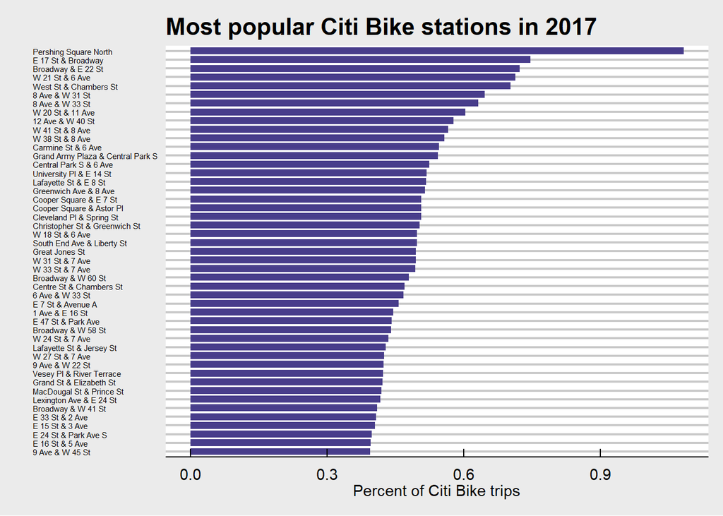

```r
ggplot(joinedTableUniques, aes(x = reorder(smonName, PercentOfTotal), y = PercentOfTotal)) +
  geom_col(fill = "darkslateblue", width = 0.8, position = position_dodge(width = .9)) +
  coord_flip() +
  xlab(" ") +
  ylab("Percent of Citi Bike trips") +
  ggtitle("Most popular Citi Bike stations in 2017") +
  theme_economist_white()  +
  theme(axis.text.y=element_text(size=rel(0.5)))
```

```r
# impact: we can tell the Citi Bike stations are well spread out. There aren't any stations that are excessively impacted, although there are some lesser used ones.
```

The bike stations are evenly dispersed. No one Citi Bike station is excessively impacted, although there are some lesser used stations not included on the graph. New York City hosts nearly 1,200 miles of bike paths, but only 471 miles of these paths are protected from car traffic by physical barriers. Since its launch in 2013, Citi Bike has become an integral part of New York’s commuting culture, accounting for almost 65 million rides thus far.

The first fatal Citi Bike accident occurred on June 12, 2017, when a fifty-thousand pound Coach USA bus struck a 36-year old investment banker, who was married with two children. The bus driver allegedly attempted to pass the cyclist after beeping his horn. The bus driver was later found guilty of failing to yield to the Citi Bike rider.

Then in April 2019, a 74-year-old cyclist collided with a UPS truck on 11th Avenue. Although the cyclist survived the accident, he sustained serious bodily trauma including a “partially severed” leg, accrding to [a neighborhood news website, Gotamist](http://gothamist.com/2019/04/29/citi_bike_cyclist_hudson_yards.php). In this case, the driver was cleared of any wrongdoing. These examples highlight a couple of the more serious accidents between Citi Bike users and motor vehicles. There are many more incidents and close calls that do not make the front page but still have the potential to be very dangerous. These two incidents also illustrate that the issue is not one-sided; the safety of these riders is the responsibility of the cyclists and motorists alike.

“Safety is our top priority and we’re deeply concerned by this accident,” a spokesperson for Citi Bike said after the 2019 collision. “Citi Bike riders deserve safe streets.”

For this project, we wanted to look at the bike-vehicle accidents and determine whether there is a trend showing locations around the city where most car and bike collisions occur.

```r
nyc_crashes <- read_csv(file = "NYPD_Motor_Vehicle_CollisionsSmall.csv")

#this imports a CSV file that is a subset of a New york City open data table on the city's car crashes. You need this NYPD_Motor_Vehicle_CollisionsSmall.csv in the zip file. It will not work unless this is in the zip file.
```

```r
nyc_crashes_bike <- nyc_crashes %>%
  filter(!is.na(LATITUDE)) %>%
  filter(!is.na(LONGITUDE)) %>%
  filter(bike_injuries > 0 | bike_deaths > 0)

#this only chooses the car crashes that involved a bike.
```

```r
bike_crashes_tidy <- nyc_crashes_bike %>%
  dplyr::select(DATE, LONGITUDE, LATITUDE, bike_injuries, bike_deaths) %>%
  dplyr::mutate(FullDate = mdy(DATE)) %>%
  separate(FullDate, sep="-", into = c("year", "month", "day")) %>%
  filter(LONGITUDE != 0, LATITUDE != 0) %>%
  filter(year == 2018 | year == 2017)

#this finds recent bike crashes based on the year being 2017 or 2018
```

```r
bike_icon <- icons(iconUrl = "bike_icon.png", 10, 10)

#we have a bike icon in the zip file. This calls it. You need that png to make the call function work.
```

```r
leaflet(bikeStations) %>%
  addTiles() %>%
  addMarkers(~bikeStations$lon, ~bikeStations$lat, icon = bike_icon) %>%
  addCircles(~bike_crashes_tidy$LONGITUDE, bike_crashes_tidy$LATITUDE, weight = 1.5, radius = 20,
             fill = ~bike_crashes_tidy$bike_deaths, color = 'red', stroke = TRUE, fillOpacity = 1)
```

[interactive chart not shown]

```r
#this applies layers for bike stations and bike injuries to the map.
```

There are more collisions in the boroughs surrounding the Citi Bike stations. We plotted all bike stations and then graphed red open circles as an injured cyclist and filled circles as a killed cyclist. looking at trends in the areas with the most accidents.

While it is tempting to conclude that Citi Bikes are causing the accidents, but it is important to note that the crash data does not distinguish between Citi Bikes and regular bikes. It is likely that the concentrated car-on-bike crashes around stations simply reflect a higher concentration of bikes on the road, especially given that Citi Bike had an incentive to put stations in bike-friendly neighborhoods that already got a lot of cycling traffic. Another possibility is that the Citi Bike neighborhoods are in areas frequented by tourists, who are more likely to be distracted rather than practicing defensive cycling tactics.

[^1]

[^1]: [Github Repository](https://github.com/SarahGillespie/sds192-mp4)